# Assignment 3: Supervised learning competition

Authors

Ilse van Deventer (9996974)

Majdouline Hamdi (9767738)

Zexuan Li (8069182)

Zoé Ricardie (9107096)

Menno Zoetbrood (1084720)

Published

October 20, 2025

## Data Description

This report aims to predict student academic performance using datasets collected from two schools. The available data include a variety of social factors (e.g. parental education, family income), and academic factors (e.g. study time, participation in extracurricular activities). These attributes act as potential predictors of the variable `score` and allow for holistic data analysis of how social and educational factors influence student performance (see Table 1).

Previous research shows the significant role social factors, such as socio-economic status, play in student performance (e.g. Rakesh et al., 2024; Munir et al., 2023). Thus, the dataset provides sufficient and diverse features to justify a comprehensive predictive analysis.

```r
# Create metadata table
var_info <- tribble(
  ~No, ~Variable, ~Description, ~Type, ~Possible_Values,
  1, "school", "Student’s school", "factor", '"GP" – Gabriel Pereira, "MS" – Mousinho da Silveira',
  2, "sex", "Student’s sex", "factor", '"F" – female, "M" – male',
  3, "age", "Student’s age", "numeric", "15–22",
  4, "address", "Student’s home address type", "factor", '"U" – urban, "R" – rural',
  5, "famsize", "Family size", "factor", '"LE3" – ≤3, "GT3" – >3',
  6, "Pstatus", "Parents’ cohabitation status", "factor", '"T" – together, "A" – apart',
  7, "Medu", "Mother’s education level", "numeric", "0–4 (none–higher)",
  8, "Fedu", "Father’s education level", "numeric", "0–4 (none–higher)",
  9, "Mjob", "Mother’s occupation", "factor", '"teacher", "health", "services", "at_home", "other"',
  10, "Fjob", "Father’s occupation", "factor", '"teacher", "health", "services", "at_home", "other"',
  11, "reason", "Reason for choosing school", "factor", '"home", "reputation", "course", "other"',
  12, "guardian", "Student’s guardian", "factor", '"mother", "father", "other"',
  13, "traveltime", "Home–school travel time", "numeric", "1: <15 min., 2: 15 to 30 min., 3: 30 min. to 1 hour, or 4: >1 hour)",
  14, "studytime", "Weekly study time", "numeric", "1–4 (<2 h to >10 h)",
  15, "failures", "Number of past class failures", "numeric", "0–4",
  16, "schoolsup", "Extra educational support", "factor", "yes/no",
  17, "famsup", "Family educational support", "factor", "yes/no",
  18, "paid", "Extra paid classes", "factor", "yes/no",
  19, "activities", "Participation in extra-curricular activities", "factor", "yes/no",
  20, "nursery", "Attended nursery school", "factor", "yes/no",
  21, "higher", "Aspires to higher education", "factor", "yes/no",
  22, "internet", "Internet access at home", "factor", "yes/no",
  23, "romantic", "In a romantic relationship", "factor", "yes/no",
  24, "famrel", "Quality of family relationships", "numeric", "1–5 (very bad–excellent)",
  25, "freetime", "Free time after school", "numeric", "1–5 (very low–very high)",
  26, "goout", "Going out with friends", "numeric", "1–5 (very low–very high)",
  27, "Dalc", "Workday alcohol consumption", "numeric", "1–5 (very low–very high)",
  28, "Walc", "Weekend alcohol consumption", "numeric", "1–5 (very low–very high)",
  29, "health", "Current health status", "numeric", "1–5 (very bad–very good)",
  30, "absences", "Number of school absences", "numeric", "0–93",
  31, "score", "Computed performance score", "numeric", "Continuous value"
)


# Add table to quarto document
knitr::kable(var_info, caption = "Table 1. Variable Descriptions")
```

Table 1. Variable Descriptions

| No | Variable | Description | Type | Possible_Values |
| --- | --- | --- | --- | --- |
| 1 | school | Student’s school | factor | “GP” – Gabriel Pereira, “MS” – Mousinho da Silveira |
| 2 | sex | Student’s sex | factor | “F” – female, “M” – male |
| 3 | age | Student’s age | numeric | 15–22 |
| 4 | address | Student’s home address type | factor | “U” – urban, “R” – rural |
| 5 | famsize | Family size | factor | “LE3” – ≤3, “GT3” – >3 |
| 6 | Pstatus | Parents’ cohabitation status | factor | “T” – together, “A” – apart |
| 7 | Medu | Mother’s education level | numeric | 0–4 (none–higher) |
| 8 | Fedu | Father’s education level | numeric | 0–4 (none–higher) |
| 9 | Mjob | Mother’s occupation | factor | “teacher”, “health”, “services”, “at_home”, “other” |
| 10 | Fjob | Father’s occupation | factor | “teacher”, “health”, “services”, “at_home”, “other” |
| 11 | reason | Reason for choosing school | factor | “home”, “reputation”, “course”, “other” |
| 12 | guardian | Student’s guardian | factor | “mother”, “father”, “other” |
| 13 | traveltime | Home–school travel time | numeric | 1: <15 min., 2: 15 to 30 min., 3: 30 min. to 1 hour, or 4: >1 hour) |
| 14 | studytime | Weekly study time | numeric | 1–4 (<2 h to >10 h) |
| 15 | failures | Number of past class failures | numeric | 0–4 |
| 16 | schoolsup | Extra educational support | factor | yes/no |
| 17 | famsup | Family educational support | factor | yes/no |
| 18 | paid | Extra paid classes | factor | yes/no |
| 19 | activities | Participation in extra-curricular activities | factor | yes/no |
| 20 | nursery | Attended nursery school | factor | yes/no |
| 21 | higher | Aspires to higher education | factor | yes/no |
| 22 | internet | Internet access at home | factor | yes/no |
| 23 | romantic | In a romantic relationship | factor | yes/no |
| 24 | famrel | Quality of family relationships | numeric | 1–5 (very bad–excellent) |
| 25 | freetime | Free time after school | numeric | 1–5 (very low–very high) |
| 26 | goout | Going out with friends | numeric | 1–5 (very low–very high) |
| 27 | Dalc | Workday alcohol consumption | numeric | 1–5 (very low–very high) |
| 28 | Walc | Weekend alcohol consumption | numeric | 1–5 (very low–very high) |
| 29 | health | Current health status | numeric | 1–5 (very bad–very good) |
| 30 | absences | Number of school absences | numeric | 0–93 |
| 31 | score | Computed performance score | numeric | Continuous value |

## Exploratory Data Analysis

To explore and understand the data, we followed Peng’s Exploratory Data Analysis (EDA) Checklist (Komorowski et al., 2016), which emphasises a structured, reproducible approach to data familiarization and validation.

Although our goal is not to answer a specific research question, this framework ensures a systematic process for identifying which variables best predict a student’s score and evaluating different predictive models.

After loading the dataset, we examined the first and last rows to verify that it was read correctly. The data contains 395 total students. The data gets split into two datasets, a training dataset and a test dataset. The training dataset includes 276 students attending Gabriel Pereira (GP), and 40 attending Mousinho da Silveira (MS), having a total of 316 students. Furthermore, the training dataset contains 31 variables, of which 30 are predictors, with the other being our target variable `score`, representing a normalised exam grade. The test dataset contains the remaining 79 students, containing 30 variables, omitting the `score` variable.

### Preprocessing for EDA

Before conducting the EDA, we performed a series of Preprocessing steps to make the dataset interpretable and ready for visualisation. Ordinal variables such as parental education (`Medu`, `Fedu`), study-time, and travel time were converted into labelled factors with meaningful descriptions. Binary variables (e.g. `romantic`, `higher`) were mapped to 0/1 format for consistency, and categorical variables were grouped into numeric, ordinal, nominal, and binary sets to support targeted plotting.

In addition, one-hot encoding was applied to the main categorical variables to allow for bar plot visualisation and maintain categorical integrity during correlation inspection. These transformations ensured that all EDA figures reflected the underlying data structure accurately and consistently.

```r
#| label: EDA Preprocessing
#| include: False

# Create a copy of train_data
train_data_pre <- train_data

# Transferring ordered ordinal into factors
edu_map <- c("none", "primary (4th grade)", "5th to 9th grade", "secondary", "higher education")
traveltime_map <- c("<15 min", "15–30 min", "30 min–1 hour", ">1 hour")
studytime_map <- c("<2 hours", "2–5 hours", "5–10 hours", ">10 hours")

train_data_pre$Medu <- factor(train_data_pre$Medu, levels = 0:4, labels = edu_map)
train_data_pre$Fedu <- factor(train_data_pre$Fedu, levels = 0:4, labels = edu_map)
train_data_pre$traveltime <- factor(train_data_pre$traveltime, levels = 1:4, labels = traveltime_map)
train_data_pre$studytime <- factor(train_data_pre$studytime, levels = 1:4, labels = studytime_map)

# Create vectors depend on data type
numeric_ordinal <- c("failures","famrel","freetime","goout","Dalc","Walc","health")

ordered_ordinal <- c("Medu","Fedu","traveltime","studytime")

nominal_cols <- c("Mjob","Fjob","reason","guardian")

binary_cols <- c("school","sex","address","famsize","Pstatus",
                 "schoolsup","famsup","paid","activities","nursery",
                 "higher","internet","romantic")

numeric_cols <- c("absences", "age","score")

# Transfer numeric_ordinal into factor
train_data_pre[numeric_ordinal] <- lapply(train_data_pre[numeric_ordinal], as.factor)


#---

# Making another copy for train data for encoding
train_data_encode<-train_data_pre

# Transfer Binary into 0/1
binary_mapping <- list(
  school = c("GP" = 1, "MS" = 0),
  sex = c("F" = 1, "M" = 0),
  address = c("U" = 1, "R" = 0),
  famsize = c("LE3" = 1, "GT3" = 0),
  Pstatus = c("T" = 1, "A" = 0),
  schoolsup = c("yes" = 1, "no" = 0),
  famsup = c("yes" = 1, "no" = 0),
  paid = c("yes" = 1, "no" = 0),
  activities = c("yes" = 1, "no" = 0),
  nursery = c("yes" = 1, "no" = 0),
  higher = c("yes" = 1, "no" = 0),
  internet = c("yes" = 1, "no" = 0),
  romantic = c("yes" = 1, "no" = 0)
)

for(col in names(binary_mapping)) {
  train_data_encode[[col]] <- as.numeric(binary_mapping[[col]][train_data_encode[[col]]])
}

# One-Hot encoding
dummy_model <- dummyVars(~ Medu + Fedu + traveltime + studytime + Mjob + Fjob + reason + guardian,
                        data = train_data_encode,
                        fullRank = FALSE)

dummy_data <- predict(dummy_model, newdata = train_data_encode)

train_data_encode <- cbind(
  train_data_encode %>% dplyr::select(-Medu, -Fedu, -traveltime, -studytime, -Mjob, -Fjob, -reason, -guardian),
  as.data.frame(dummy_data)
)
```

`Score` was already normalised, with a mean of −0.02 (SD = 0.99), indicating a near-zero mean and unit variance. Therefore, no additional transformation or scaling was required for the dependent variable.

```r
#| label: Mean and Std. Dev. for Score

# Compute statistic score for data

stat_score <- train_data %>%
  summarize(mean(score),
            sd (score))

stat_score
```

| mean(score) | sd(score) |
| --- | --- |
| -0.0161966 | 0.9862094 |

### Visualisation

##### Univariate Analysis

To better understand the data, we created five different bar plots, grouped by variable type. This was an intentional decision to keep each figure remaining clear, interpretable, and directly linked to their analytical role: Figure 1 shows the ordered numeric variables, such as alcohol consumption (`Dalc`, `Walc`) and free time. The distributions highlight that most students report low alcohol consumption and good family relationships, with health and social activity levels being more varied.

Figure 2 displays ordered categorical variables, including parental education (`Fedu`, `Medu`), and travel time. These are ordinal by nature as they provide a meaningful order. Therefore, separating them into their own plot allows us to interpret trends such as the vast amount of parents with secondary or higher education, and the majority of students having their travel time to school being less than fifteen minutes.

Figure 4 depicts the continuous numeric variables. The absences variable is noticeably right-skewed, indicating that most students attend regularly, with only a few exhibiting high absence counts. The age distribution shows that the majority of students are between 15 and 18 years old, while the score variable follows an approximately normal distribution, making it well-suited for regression-based modelling. Specifically, students’ ages range from 15 to 22 years (M = 16.75, SD = 1.30), providing sufficient variation to capture academic outcomes across both early and late adolescence.

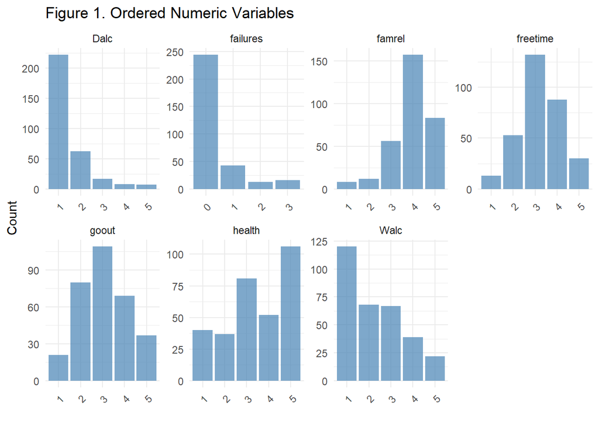

```r
#| label: Frequencies plot

# Visualise Ordered Numeric data
train_data_pre %>%
  dplyr::select(dplyr::all_of(numeric_ordinal)) %>%
  tidyr::gather() %>%
  ggplot(aes(value)) +
  geom_bar(fill = "steelblue", alpha = 0.7) +
  facet_wrap(~key, scales = "free", ncol = 4) +
  theme_minimal() +
  theme(axis.text.x = element_text(angle = 45, hjust = 1)) +
  labs(title = "Figure 1. Ordered Numeric Variables", x = "", y = "Count")
```

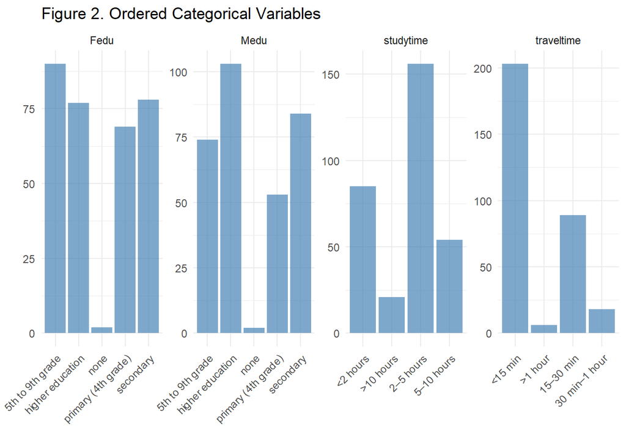

```r
# Visualise Ordered Categorical data
train_data_pre %>%
  dplyr::select(dplyr::all_of(ordered_ordinal)) %>%
  tidyr::gather() %>%
  ggplot(aes(value)) +
  geom_bar(fill = "steelblue", alpha = 0.7) +
  facet_wrap(~key, scales = "free", ncol = 4) +
  theme_minimal() +
  theme(axis.text.x = element_text(angle = 45, hjust = 1)) +
  labs(title = "Figure 2. Ordered Categorical Variables", x = "", y = "")
```

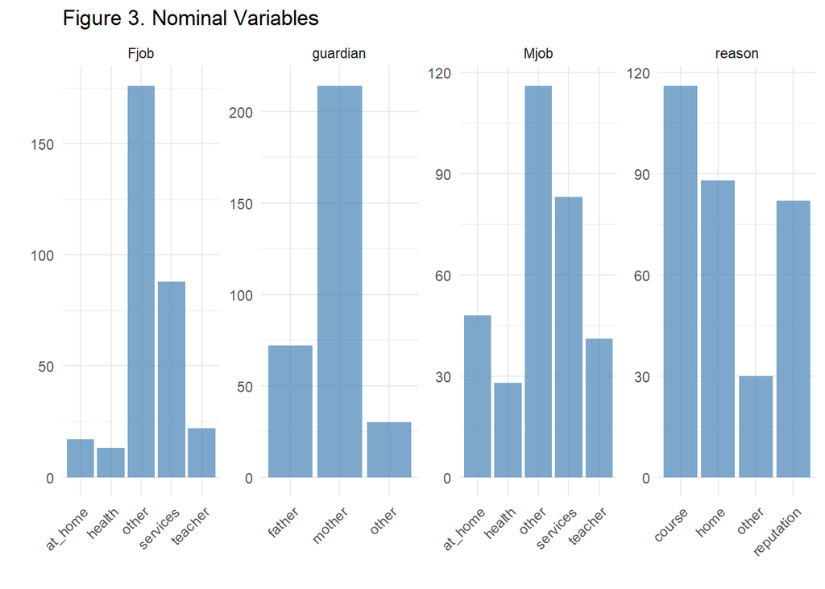

```r
# Visualise Nominal data
train_data_pre %>%
  dplyr::select(dplyr::all_of(nominal_cols)) %>%
  tidyr::gather() %>%
  ggplot(aes(value)) +
  geom_bar(fill = "steelblue", alpha = 0.7) +
  facet_wrap(~key, scales = "free", ncol = 4) +
  theme_minimal() +
  theme(axis.text.x = element_text(angle = 45, hjust = 1)) +
  labs(title = "Figure 3. Nominal Variables", x = "", y = "")
```

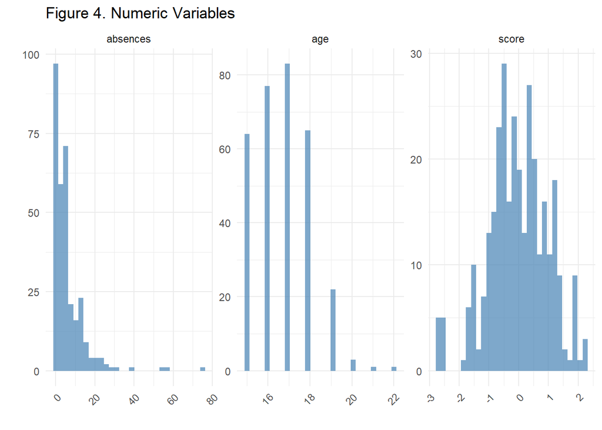

```r
# Visualise Numeric data
train_data_pre %>%
  dplyr::select(dplyr::all_of(numeric_cols)) %>%
  tidyr::gather() %>%
  ggplot(aes(value)) +
  geom_histogram(fill = "steelblue", alpha = 0.7) +
  facet_wrap(~key, scales = "free", ncol = 4) +
  theme_minimal() +
  theme(axis.text.x = element_text(angle = 45, hjust = 1)) +
  labs(title = "Figure 4. Numeric Variables", x = "", y = "")
```

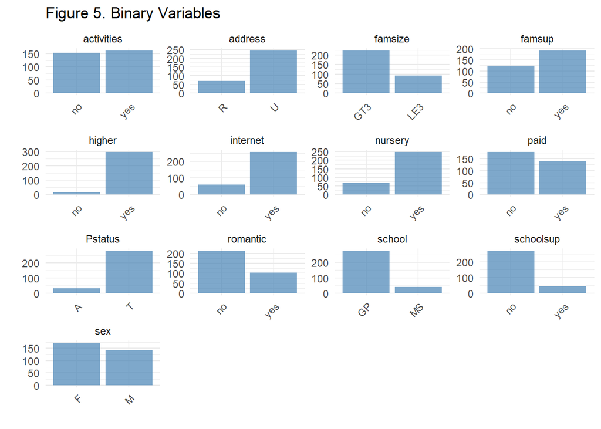

```r
# Visualise Binary data
train_data_pre %>%
  dplyr::select(dplyr::all_of(binary_cols)) %>%
  tidyr::gather() %>%
  ggplot(aes(value)) +
  geom_bar(fill = "steelblue", alpha = 0.7) +
  facet_wrap(~key, scales = "free", ncol = 4) +
  theme_minimal() +
  theme(axis.text.x = element_text(angle = 45, hjust = 1)) +
  labs(title = "Figure 5. Binary Variables", x = "", y = "")
```

##### Bivariate Analysis

###### Correlation Analysis

To examine how numerical variables relate to one another and to the target variable score, we generated a correlation heatmap (see Figure 6). This visualisation provides an overview of linear relationships between predictors and helps identify potential multicollinearity issues that could affect model performance.

Figure 6 shows that most correlations are relatively weak, implying that the data does not contain strong redundancy between predictors. Additionally, our strongest positive correlations are between mother’s education `Medu` and father’s education `Fedu` (r = 0.61), and between weekday alcohol consumption `Dalc` and weekend alcohol consumption `Walc` (r = 0.63). The correlation for education level is expected as parental education levels tend to be similar within households (Erola et al., 2016), and for alcohol consumption, it indicates a consistent drinking pattern across the week.

Thus, the heatmap provides a concise summary of inter-variable dependencies, affirming that, while some variables are relatively interrelated, most predictors provide unique information, making their inclusion in the following modeling steps sufficient.

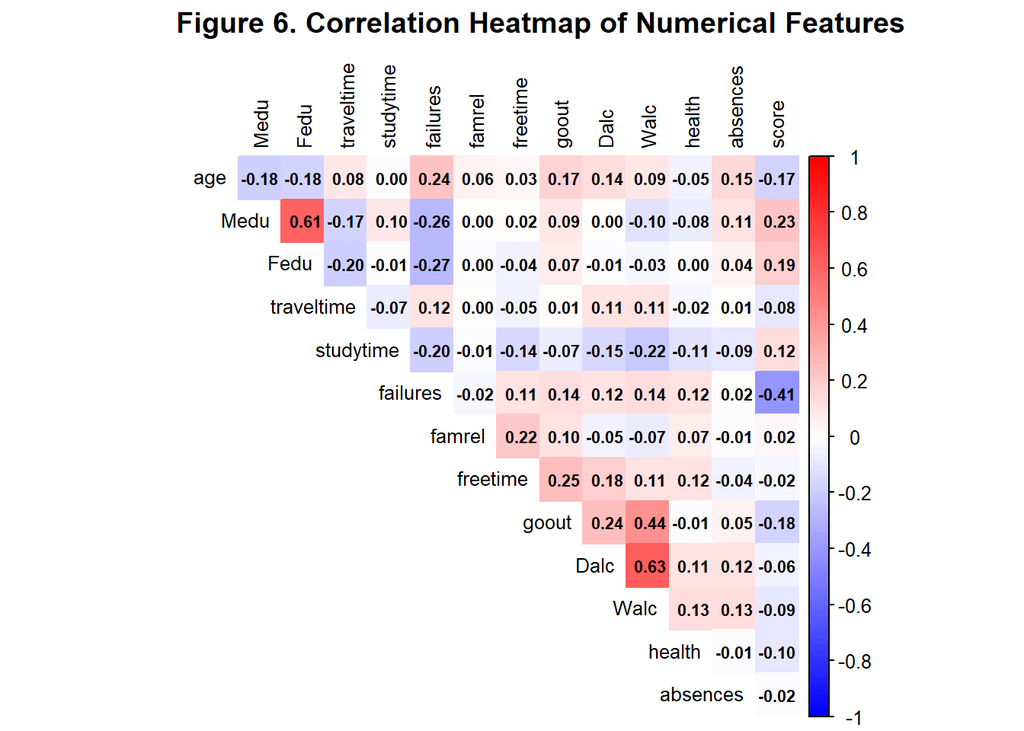

```r
#| label: Correlation Heatmap


# Calculate correlation matrix only with numeric columns from original data
corr <- cor(train_data[,sapply(train_data, is.numeric)], use = "complete.obs")

# Create correlation heatmap
corrplot(corr,
         method = "color",
         type = "upper",
         order = "original",
         diag = FALSE,
         tl.cex = 0.8,
         tl.col = "black",
         number.cex = 0.7,
         addCoef.col = "black",
         col = colorRampPalette(c("blue", "white", "red"))(100),
         mar = c(0, 0, 2, 0))

title("Figure 6. Correlation Heatmap of Numerical Features", line = 3)
```

###### Data Exploration and Variable Relationships

Having examined the numeric variables and their correlations through the heatmap (Figure 6), we now turn to how categorical predictors relate to students’ exam performance.

Before delving into categorical analyses, we briefly inspected the distributions of numeric variables using boxplots. While most features showed expected variation, a few outliers were observed. Notably, unusually high values for absences (Figure 13) and a small number of older students relative to the rest of the cohort (Figure 8). As these observations appeared to reflect genuine cases rather than data entry errors, they were retained in the dataset.

We also analysed how the categorical variables of our dataset correlate with students’ exam scores.

###### Demographics

Figure 7 shows the distribution of scores by sex. Males have slighly higher median scores than females, but there is considerable variability within both groups.

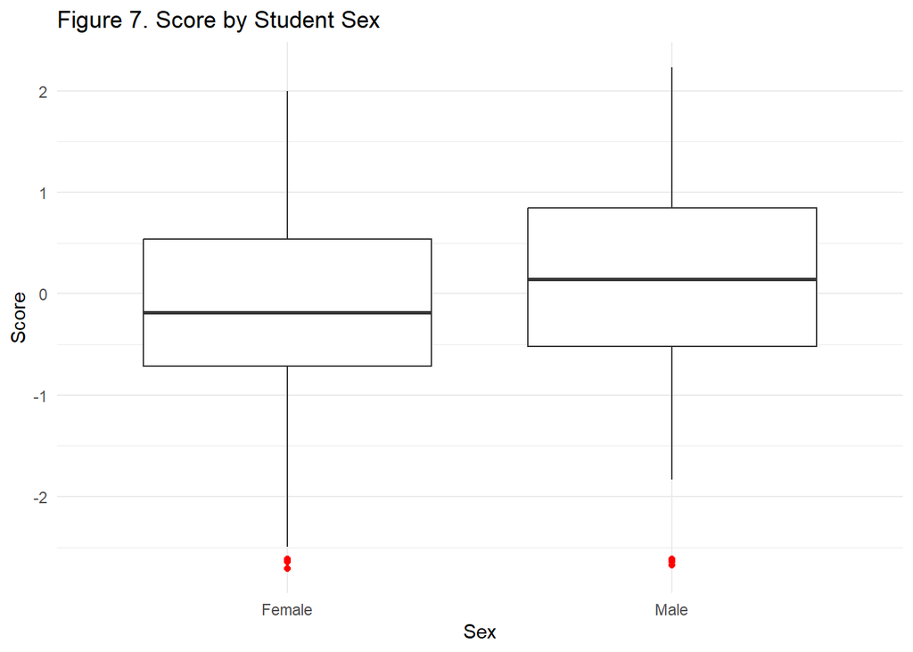

```r
#|: label: Demographics


# Visualise boxplot by score by sex
ggplot(train_data, aes(x = sex, y = score)) +
  geom_boxplot(outlier.colour = 'red') +
  scale_x_discrete(labels = c("F" = "Female", "M" = "Male")) +
  labs( x = "Sex", y = "Score",  title = "Figure 7. Score by Student Sex") +
  theme_minimal()
```

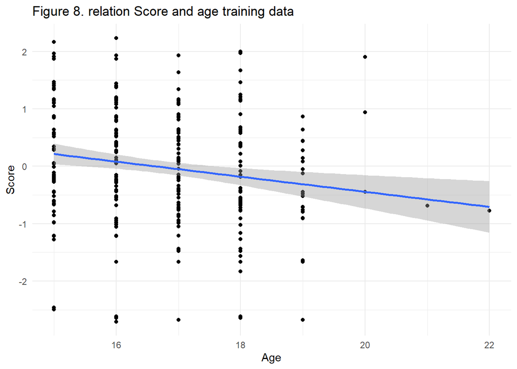

```r
# Visualise score by age
ggplot(train_data, aes(age, score)) +
  geom_point() +
  geom_smooth(method = "lm") + # Score and age negative relation, seems linear.
  theme_minimal()+
  labs( x = "Age", y = "Score",  title = "Figure 8. relation Score and age training data ")
```

###### General Home Situation

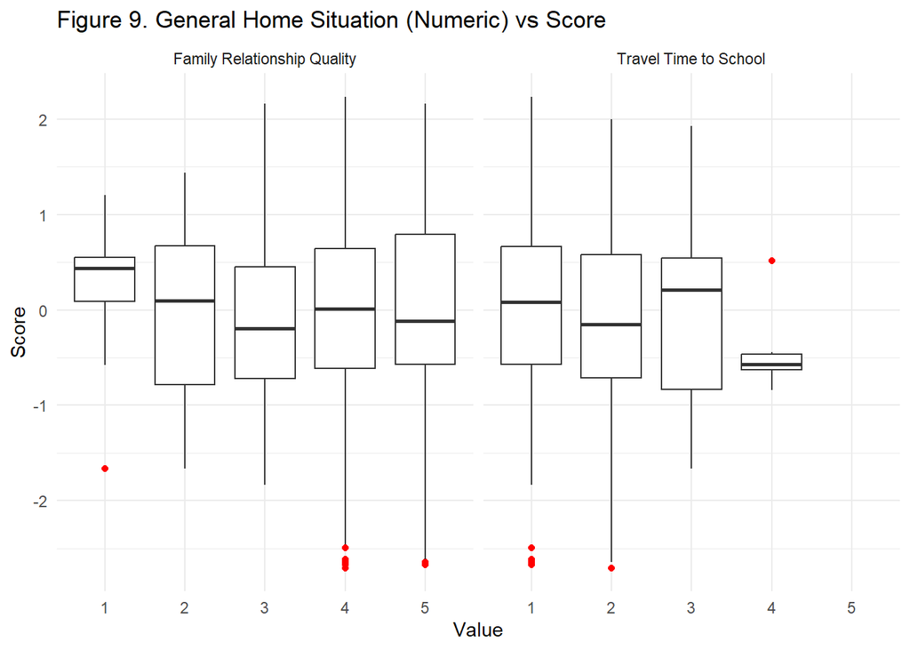

```r
#| label: Visual Home Situation (General)

# Create vectors for split visual num & cat.
num_home_general <- c("traveltime", "famrel")
cat_home_general <- c("address", "famsize", "Pstatus", "guardian")


# Recode categorical variables labels for readability
train_data_plot <- train_data |>
  mutate(
    address = recode(address, "U" = "Urban", "R" = "Rural"),
    famsize = recode(famsize, "LE3" = "≤3", "GT3" = ">3"),
    Pstatus = recode(Pstatus, "T" = "Together", "A" = "Apart"))


# Make vector for titles plot
understandable_labels_plot_home_situ <- c(
  address = "Home Address",
  famsize = "Family Size",
  Pstatus = "Parents' Cohabitation",
  guardian = "Guardian",
  traveltime = "Travel Time to School",
  famrel = "Family Relationship Quality")

# Numeric plot with nice facet labels
train_data_plot |>
  pivot_longer(all_of(num_home_general), names_to = "variable", values_to = "value") |>
  ggplot(aes(x = factor(value), y = score)) +
  geom_boxplot(outlier.colour = "red") +
  facet_wrap(~variable,  ncol = 2, labeller = labeller(variable = understandable_labels_plot_home_situ)) +
  labs( title = "Figure 9. General Home Situation (Numeric) vs Score", x = "Value", y = "Score") +
  theme_minimal()
```

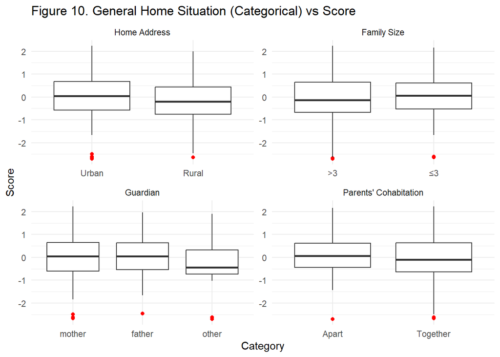

```r
# Categorical plot with nice facet labels
train_data_plot |>
  pivot_longer(all_of(cat_home_general), names_to = "variable", values_to = "value") |>
  ggplot(aes(x = value, y = score)) +
  geom_boxplot(outlier.colour = "red") +
  facet_wrap(~variable,  scales = "free", labeller = labeller(variable = understandable_labels_plot_home_situ)) +
  labs(title = "Figure 10. General Home Situation (Categorical) vs Score",  x = "Category", y = "Score" ) +
  theme_minimal()
```

###### Home Situation (School Related)

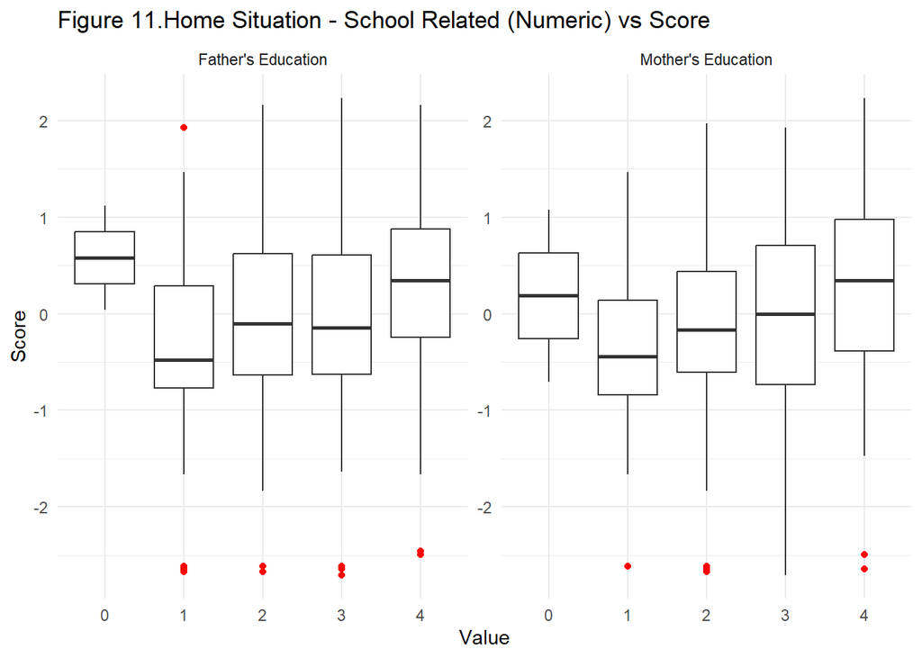

```r
#| label: Visual Home Situation (School Related)

num_home_school <- c("Medu", "Fedu")
cat_home_school <- c("Mjob", "Fjob", "famsup", "internet", "nursery")


# Make vector for titles plot
nice_labels_school <- c(
  Medu = "Mother's Education",
  Fedu = "Father's Education",
  Mjob = "Mother's Job",
  Fjob = "Father's Job",
  famsup = "Family Educational Support",
  internet = "Internet Access",
  nursery = "Attended Nursery"
)

# Numeric plot
train_data |>
  pivot_longer(all_of(num_home_school), names_to = "variable", values_to = "value") |>
  ggplot(aes(x = factor(value), y = score)) +
  geom_boxplot(outlier.colour = "red") +
  facet_wrap(~variable, scales = "free", ncol = 2, labeller = labeller(variable = nice_labels_school)) +
  labs(title = "Figure 11.Home Situation - School Related (Numeric) vs Score", x = "Value", y = "Score") +
  theme_minimal()
```

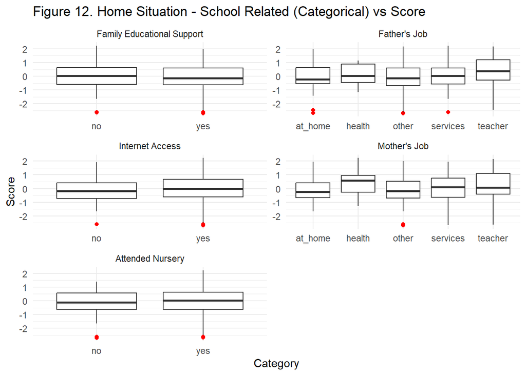

```r
# Categorical plot
train_data |>
  pivot_longer(all_of(cat_home_school), names_to = "variable", values_to = "value") |>
  ggplot(aes(x = value, y = score)) +
  geom_boxplot(outlier.colour = "red") +
  facet_wrap(~variable, scales = "free", ncol = 2, labeller = labeller(variable = nice_labels_school)) +
  labs(title = "Figure 12. Home Situation - School Related (Categorical) vs Score", x = "Category", y = "Score") +
  theme_minimal()
```

###### School Motivation

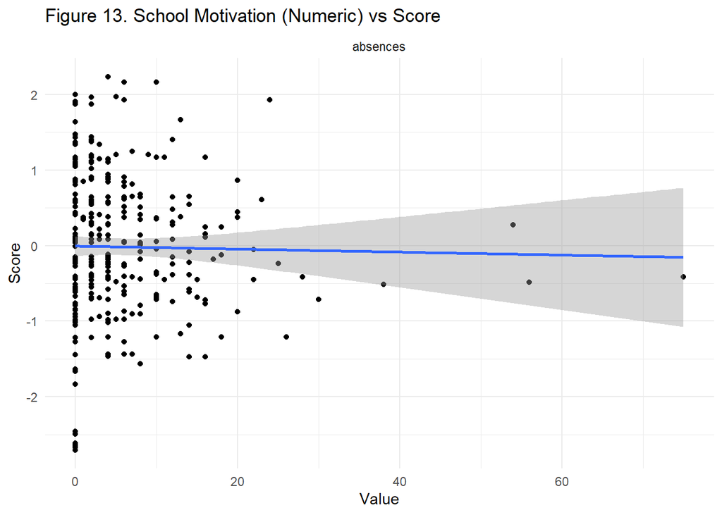

```r
#| label: School Motivation

num_school_motivation <- c("absences")
ord_school_motivation <- c("studytime", "failures")
cat_school_motivation <- c("reason", "higher")


# Make vector for titles plot
nice_labels_motivation <- c(
  absences = "Number of Absences",
  studytime = "Weekly Study Time",
  failures = "Past Class Failures",
  reason = "Reason for School Choice",
  higher = "Aspires to Higher Education"
)

# Numeric
train_data |>
  pivot_longer(all_of(num_school_motivation), names_to = "variable", values_to = "value") |>
  ggplot(aes(x = value, y = score)) +
  geom_point() +
  geom_smooth(method = "lm") +
  facet_wrap(~variable, scales = "free")+
  labs(title = "Figure 13. School Motivation (Numeric) vs Score", x = "Value",y = "Score" ) +
  theme_minimal()
```

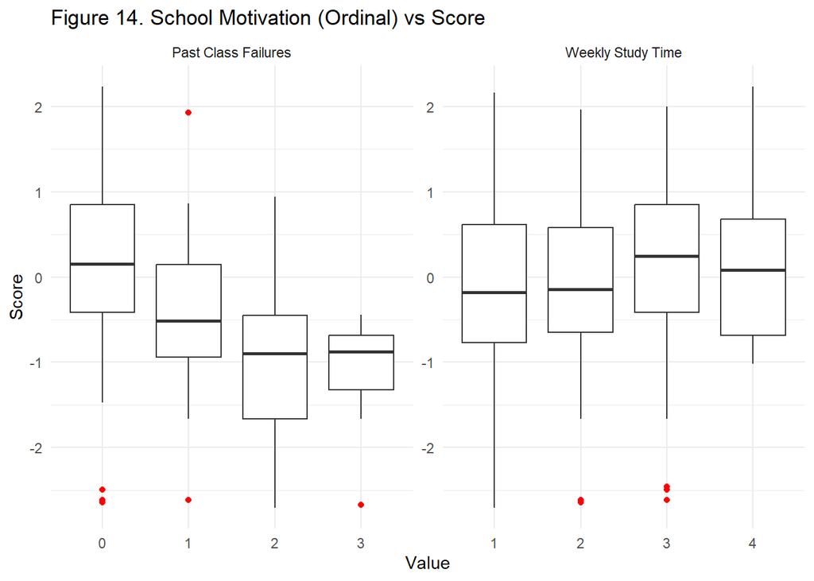

```r
# Ordinal
train_data |>
  pivot_longer(all_of(ord_school_motivation), names_to = "variable", values_to = "value") |>
  ggplot(aes(x = factor(value), y = score)) +
  geom_boxplot(outlier.colour = "red") +
  facet_wrap(~variable, scales = "free", ncol = 2, labeller = labeller(variable = nice_labels_motivation)) +
  labs(title = "Figure 14. School Motivation (Ordinal) vs Score", x = "Value", y = "Score") +
  theme_minimal()
```

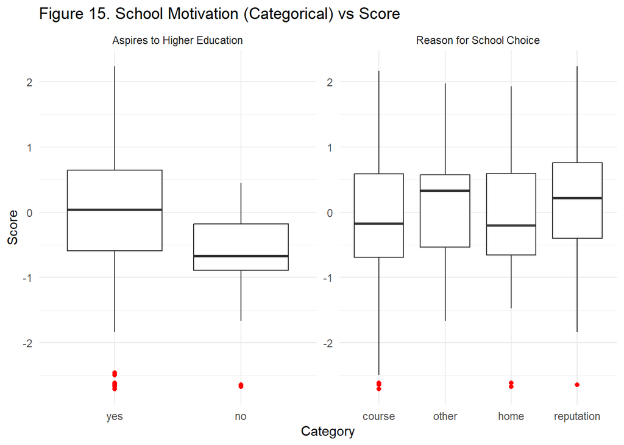

```r
# Categorical
train_data |>
  pivot_longer(all_of(cat_school_motivation), names_to = "variable", values_to = "value") |>
  ggplot(aes(x = value, y = score)) +
  geom_boxplot(outlier.colour = "red") +
  facet_wrap(~variable, scales = "free", ncol = 2, labeller = labeller(variable = nice_labels_motivation)) +
  labs(title = "Figure 15. School Motivation (Categorical) vs Score", x = "Category", y = "Score") +
  theme_minimal()
```

###### Extra Support

Next, we explored academic support variables. Figure 16 shows that students who pay for extra classes generally perform better than those who do not, while those receiving extra educational support tend to have lower mean scores. This may reflect differences in motivation: students paying for extra classes might be more proactive learners, whereas those receiving additional support could be struggling academically.

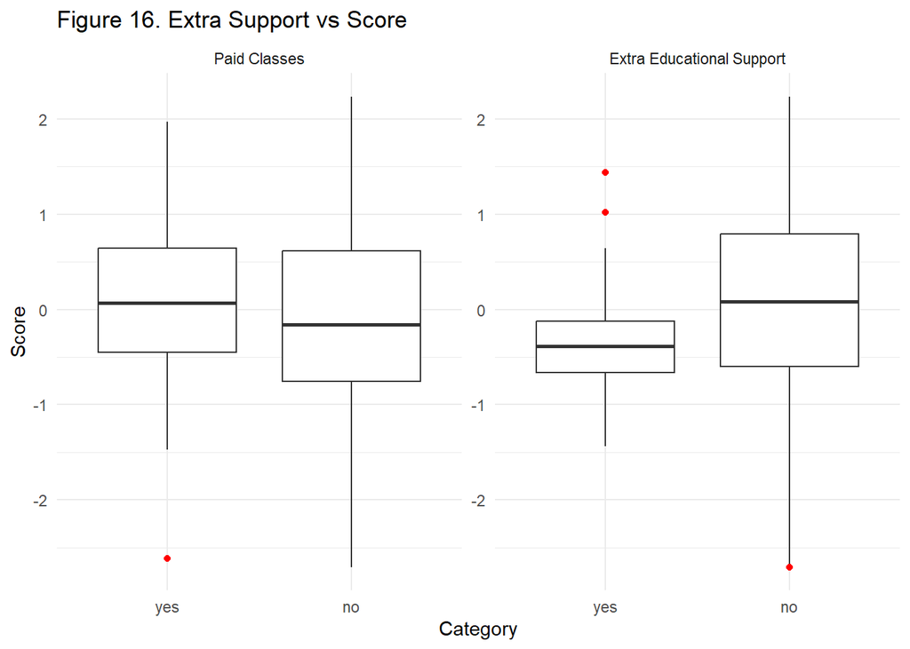

```r
#| label: Description Extra Support

cat_extra_support <- c("schoolsup", "paid")

# Make vector for titles plot
nice_labels_extra <- c(schoolsup = "Extra Educational Support", paid = "Paid Classes")

# Plot variables extra support
train_data |>
  pivot_longer(all_of(cat_extra_support), names_to = "variable", values_to = "value") |>
  ggplot(aes(x = value, y = score)) +
  geom_boxplot(outlier.colour = "red") +
  facet_wrap(~variable, scales = "free", labeller = labeller(variable = nice_labels_extra)) +
  labs(title = "Figure 16. Extra Support vs Score", x = "Category", y = "Score") +
  theme_minimal()
```

###### Check Free Time Variables

When examining lifestyle variables, Figure 18 shows that participation in extracurricular activities does not appear to influence exam performance significantly. However, students in romantic relationships tend to score slightly lower than those who are not.

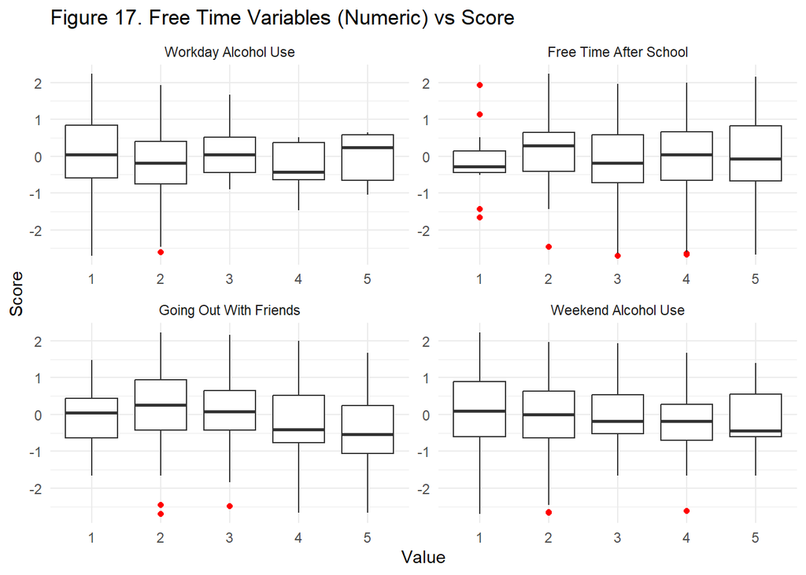

```r
#| label: Check Free Time variables


# Visualise ordinal variables

num_free_time <- c("freetime", "goout", "Dalc", "Walc")
cat_free_time <- c("activities", "romantic")

# Named vector for descriptive facet labels
nice_labels_free_time <- c(
  freetime = "Free Time After School",
  goout = "Going Out With Friends",
  Dalc = "Workday Alcohol Use",
  Walc = "Weekend Alcohol Use",
  activities = "Extra-Curricular Activities",
  romantic = "Romantic Relationship Status"
)

# Numeric plot
train_data |>
  pivot_longer(all_of(num_free_time), names_to = "variable", values_to = "value") %>%
  ggplot(aes(x = factor(value), y = score)) +
  geom_boxplot(outlier.colour = "red") +
  facet_wrap(~variable, scales = "free", ncol = 2, labeller = labeller(variable = nice_labels_free_time)) +
  labs(title = "Figure 17. Free Time Variables (Numeric) vs Score", x = "Value", y = "Score") +
  theme_minimal()
```

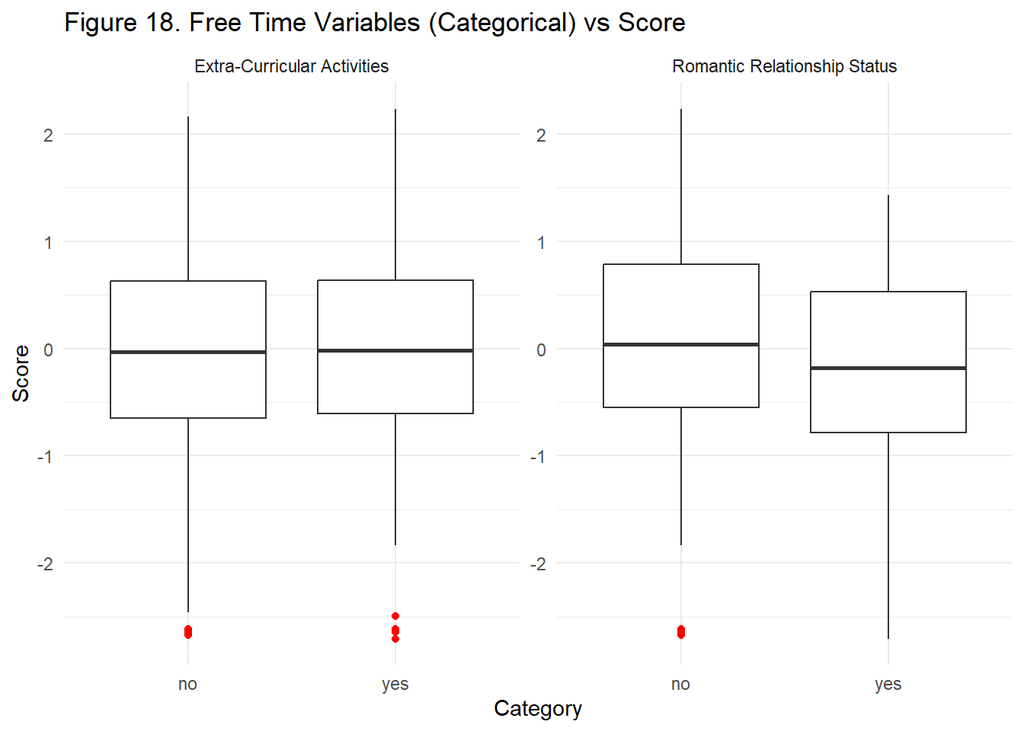

```r
# Categorical plot
train_data |>
  pivot_longer(all_of(cat_free_time), names_to = "variable", values_to = "value") |>
  ggplot(aes(x = value, y = score)) +
  geom_boxplot(outlier.colour = "red") +
  facet_wrap(~variable, scales = "free", ncol = 2, labeller = labeller(variable = nice_labels_free_time)) +
  labs(title = "Figure 18. Free Time Variables (Categorical) vs Score", x = "Category", y = "Score") +
  theme_minimal()
```

##### Other Predictors

We also explored whether the school a student attends affects their performance. Figure 20 shows that students from school GP have a higher mean score than those from school MS. However, the sample sizes are highly imbalanced (276 vs 40 students, respectively). Thus, we should interpret the mean difference cautiously — the smaller MS sample may not represent its broader student population accurately.

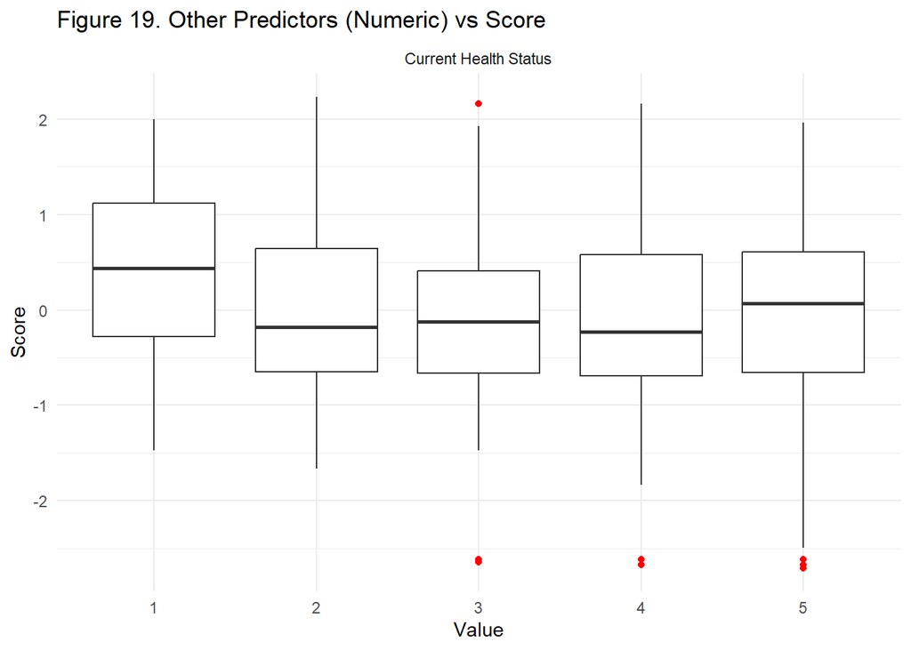

```r
#| label:  Other Predictors

num_other <- c("health")
cat_other <- c("school")

# Named vector for descriptive facet labels
nice_labels_other <- c(
  health = "Current Health Status",
  school = "School")

# Recode categorical values for readability
train_data_plot <- train_data |>
  mutate(school = recode(school, "GP" = "Gabriel Pereira", "MS" = "Mousinho da Silveira"))

# Numeric plot
train_data_plot |>
  pivot_longer(all_of(num_other), names_to = "variable", values_to = "value") |>
  ggplot(aes(x = factor(value), y = score)) +
  geom_boxplot(outlier.colour = "red") +
  facet_wrap(~variable, scales = "free", ncol = 2, labeller = labeller(variable = nice_labels_other)) +
  labs(title = "Figure 19. Other Predictors (Numeric) vs Score", x = "Value", y = "Score") +
  theme_minimal()
```

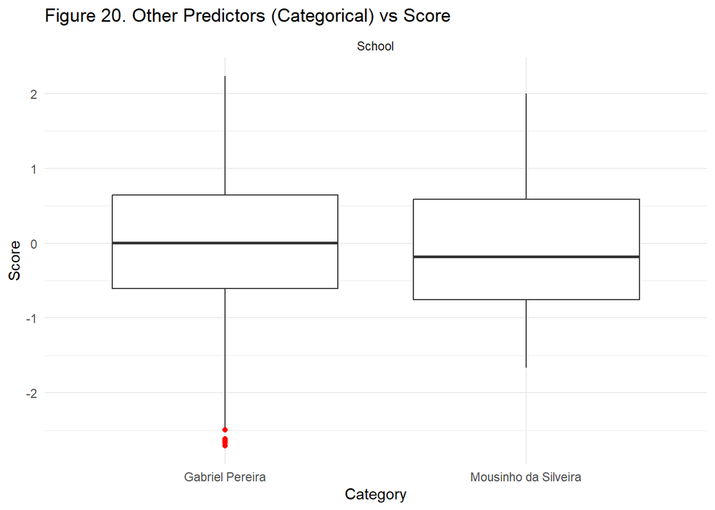

```r
# Categorical plot
train_data_plot |>
  pivot_longer(all_of(cat_other), names_to = "variable", values_to = "value") |>
  ggplot(aes(x = value, y = score)) +
  geom_boxplot(outlier.colour = "red") +
  facet_wrap(~variable, scales = "free", ncol = 2, labeller = labeller(variable = nice_labels_other)) +
  labs(title = "Figure 20. Other Predictors (Categorical) vs Score", x = "Category", y = "Score") +
  theme_minimal()
```

###### Visualise Interactions

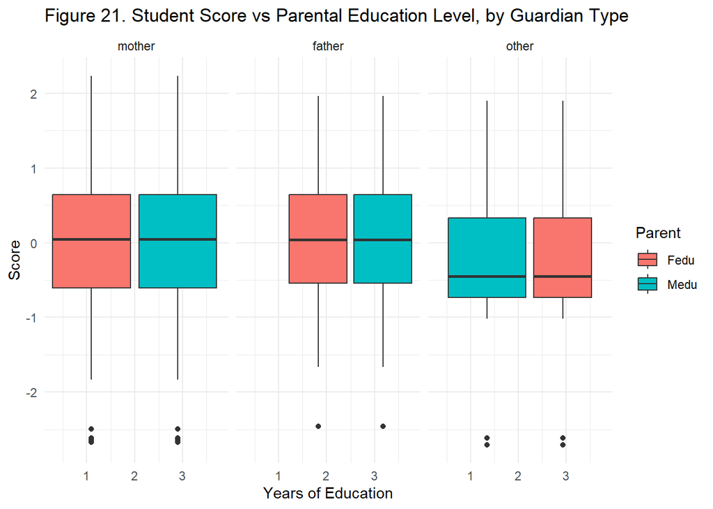

```r
#| label: Check Interaction (mom/dad/mean) Year Education & Main Guardian on Score

data_year_edu_parent <- train_data %>%
  dplyr::select(Medu, Fedu, score, guardian, famsup, famrel) %>%
  pivot_longer(
    cols = c(Medu, Fedu),
    names_to = "parent",
    values_to = "year_edu"
  )

ggplot(data_year_edu_parent, aes(x = year_edu, y = score, fill = parent)) +
  geom_boxplot() +
  facet_wrap(~ guardian) +
  labs(
    title = "Figure 21. Student Score vs Parental Education Level, by Guardian Type",
    x = "Years of Education",
    y = "Score",
    fill = "Parent"
  ) +
  theme_minimal()
```

```r
# Check main caregiver & year education
data_year_edu_main_caregiver <- train_data |>
  mutate(
    year_edu_main_caregiver = case_when(
      guardian == "mother" ~ Medu,
      guardian == "father" ~ Fedu,
      guardian == "other"  ~ NA_real_))

cor_test_year_edu_main_care <- cor.test(data_year_edu_main_caregiver$year_edu_main_caregiver, data_year_edu_main_caregiver$score, method = "spearman")

# Mean Parent Years of Edu. & Score
year_edu_mean_parents <- train_data |>
  mutate(parent_edu_avg = (Medu + Fedu) / 2)

cor_test_mean_edu <- cor.test(year_edu_mean_parents$parent_edu_avg, year_edu_mean_parents$score, method = "spearman")
```

Lastly, two dummy variables were created to capture the caregiver’s identity: `main_caregiver_mom` and `main_caregiver_dad`. Each takes the value 1 if the primary guardian is the specified caregiver, and 0 otherwise. These indicators may later be used in regression analyses as potential interaction terms to test whether the influence of parental education differs depending on which parent serves as the main caregiver.

```r
#| label: Dummy Variables for the Caregivers

# Create dummy variable main parent mom and main parent dad
train_linear <- train_data %>%
  mutate(
    main_caregiver_mom = case_when(
      guardian == "mother" ~ 1,
      guardian == "father" ~ 0,
      guardian == "other"  ~ 0
    ),
    main_caregiver_dad = case_when(
      guardian == "mother" ~ 0,
      guardian == "father" ~ 1,
      guardian == "other"  ~ 0
    )
  )

data_job_main_parent <- train_data %>%
  mutate(
    job_main_parent = case_when(
      guardian == "mother" ~ as.character(Mjob),
      guardian == "father" ~ as.character(Fjob),
      guardian == "other"  ~ "other"
    )
  )
```

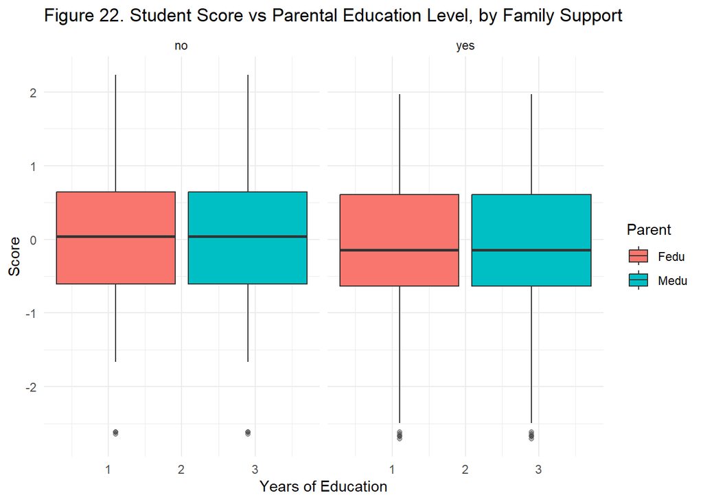

```r
ggplot(data_year_edu_parent, aes(x = year_edu, y = score, fill = parent)) +
  geom_boxplot(outlier.alpha = 0.4, width = 0.6) +
  facet_wrap(~ famsup) +
  labs(
    title = "Figure 22. Student Score vs Parental Education Level, by Family Support",
    x = "Years of Education",
    y = "Score",
    fill = "Parent"
  ) +
  theme_minimal()
```

# Model description

This study predicts student performance using three models: Linear Regression, k-Nearest Neighbours (KNN), and Random Forest. These models are used to identify the algorithm achieving the best predictive accuracy on the test set.

Linear Regression serves as the baseline model, providing interpretability and allowing estimation of both the direction and magnitude of relationships between predictors and exam scores. Stepwise selection methods (forward, backward, and mixed) were employed to identify the most informative subset of predictors while reducing redundancy.

K-Nearest Neighbours (KNN) provides a non-parametric alternative capable of modelling non-linear relationships. Its performance depends on the choice of k and on proper scaling of predictors, which was handled during the pre-processing stage.

Random Forest is an ensemble learning approach that combines multiple decision trees to improve predictive accuracy and mitigate overfitting. It can handle mixed variable types effectively and provides feature importance measures, enhancing both robustness and interpretability. For each predictive algorithm, three versions of the model were trained and evaluated to assess how data representation and feature selection influenced performance. Each model was developed using the following versions of the dataset:

-Original Feature Model This baseline model was trained using the dataset in its original structure without any feature reduction or transformation.

-Feature-Selection Model (Linear Regression only) Linear regression was trained using a feature-selection encoding method that reduced dimensionality by retaining only the most informative variables while encoding categorical data. This approach balanced model simplicity and predictive power by minimizing redundancy among correlated predictors.

-One-hot encoding Model (KNN and Random Forest only). This model converts categorical data into a numerical format suitable for these algorithms, preventing the model from inferring any ordinal relationships between categories. This representation helps avoid bias and typically improves overall predictive performance.

Feature selection was used only to the linear regression model because linear models are highly sensitive to multicollinearity and the inclusion of irrelevant predictors. Feature selection mitigates these issues.

Each model variant was evaluated using Mean Squared Error (MSE) and R² on both training and test sets. The best-performing variant for each algorithm was carried forward to the final model comparison.

This systematic design ensured that each algorithm was assessed fairly, accounting for differences in feature representation and predictor relevance, while mitigating redundancy and overfitting.

### Linear regression model

To refine the linear model, we first applied three stepwise selection approaches. First, forward selection which adds predictors sequentially based on model improvement. It starts with an empty model and adds predictors one by one. At each step, the variable that most improves model fit is included until no further improvement is achieved.

After that we used backward selection, which removes the least significant variables until only relevant ones remain. It begins with all predictors in the model and removes predictors that are least significant.

Finally, we will used mixed selection (stepwise), this combines both approaches so it adds variables like forward selection, but it also removes variables when a variable is becomes non-significant when a new variable is added. This helps prevent that redundant variables are in the dataset.

After, the stepwise selection approaches, we also did a selection by hand by first running a linear regression with all variables included after which we selected the significant variables. We also run the same regression including the interaction terms Father job x main_caregiver_dad, and Mother job x main_caregiver_mom, the variables we created earlier in the pre-processing.

Finally, we will compare the different linear models.

1. Method 1: Linear regression stepwise selection

```r
# Set seed for linear regression model
set.seed(2025)


train_control <- trainControl(method = "cv",number = 10, savePredictions = "final") #K-fold crossvalidation, set k= 10


# Linear regression with Backward selection
model_lm_backward <- train(
  score ~ .,
  data = train_linear,
  method = "lmStepAIC",
  trace = FALSE,
  direction = "backward",#set method to step backward
  trControl = train_control)
#tidy(model_lm_backward$finalModel)

# Linear regresion with Forward selection
model_lm_forward <- train(
  score ~ .,
  data = train_linear,
  method = "lmStepAIC",
  direction = "forward", #set method to step forward
  trace = FALSE,       # suppress stepwise printing
  trControl = train_control)
 #tidy(model_lm_forward$finalModel)


# Linear regression with Stepwise (both)
model_lm_both <- train(
  score ~ .,
  data = train_linear,
  method = "lmStepAIC",
  direction = "both",#set method to step both
  trace = FALSE,       # suppress stepwise printing
  trControl = train_control)
#tidy(model_lm_both$finalModel)

# Linear regression with all variables
regression_all_var <- train(
  score ~ .,
  data = train_linear,
  method = "lm", # for regression
  trControl = train_control)


#names(coef(model_lm_backward$finalModel))
#names(coef(model_lm_forward$finalModel))
#names(coef(model_lm_both$finalModel))
```

```r
# Compare models with original data
model_comparison_Linear <- data.frame(
  Model = c("Backward", "Forward", "Both", "All Variables"),
  RMSE = c(
    min(model_lm_backward$results$RMSE),
    min(model_lm_forward$results$RMSE),
    min(model_lm_both$results$RMSE),
    min(regression_all_var$results$RMSE)
  ),
  Rsquared = c(
    max(model_lm_backward$results$Rsquared),
    max(model_lm_forward$results$Rsquared),
    max(model_lm_both$results$Rsquared),
    max(regression_all_var$results$Rsquared)
  ),
  MAE = c(
    min(model_lm_backward$results$MAE),
    min(model_lm_forward$results$MAE),
    min(model_lm_both$results$MAE),
    min(regression_all_var$results$MAE)
  )
)
```

2. Method 2: significance feature selection + modelling

```r
sig_vars <- tidy(regression_all_var$finalModel) |>
  mutate(significance = case_when(
    p.value < 0.05 ~ "Significant (p < 0.05)",
    p.value < 0.10 ~ "Marginally significant (0.05 ≤ p < 0.10)",
    TRUE ~ "Not significant")) |>
  filter(p.value < 0.10) |>  # keep both significant and marginally significant
  arrange(p.value)


##regression only sign. predictors
sig_var <- c("failures", "sex", "schoolsup", "goout", "studytime", "romantic", "Fjob", "age")   #select significant variables and marginally significant (p between 0.5-0.1)


formula_sig_var <- as.formula(paste("score ~", paste(sig_var, collapse = "+"))) #create formula


##k-fold cross-validation
regression_sig_var <- train(
  formula_sig_var,
  data = train_linear,
  method = "lm", # for linear regression
  trControl = train_control)

#print(regression_sig_var)
#tidy(regression_sig_var$finalModel)
```

3. Method 3: Top 10 correlation feature selection + modeling

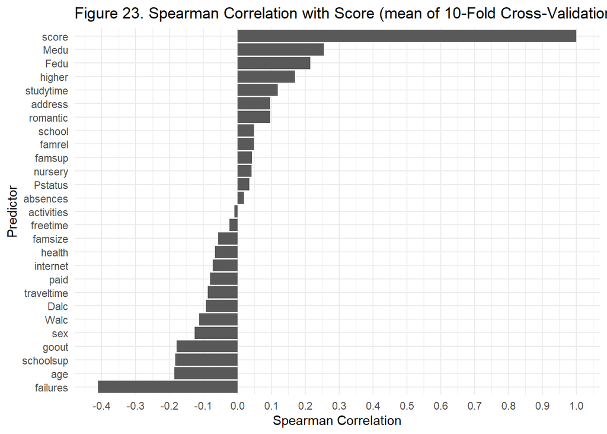

```r
# Create copy for computing matrix
train_data_cor_matrix <- train_data

# Apply mapping into matrix data
for (col in names(binary_mapping)) {
  train_data_cor_matrix[[col]] <- as.numeric(binary_mapping[[col]][train_data_cor_matrix[[col]]])
}

# Correlation computation with K-fold CV
col_all <- c(binary_cols, numeric_cols, numeric_ordinal,ordered_ordinal)
k <- 10  # number of folds

folds <- createFolds(train_data_cor_matrix$score, k = k, list = TRUE, returnTrain = TRUE)

fold_correlations <- lapply(folds, function(train_idx) {  # Store correlations for each k
  fold_data <- train_data_cor_matrix[train_idx, ]
  sapply(fold_data[, col_all], function(x) cor(x, fold_data$score, method = "spearman"))
  })

cor_score <- rowMeans(do.call(cbind, fold_correlations), na.rm = TRUE) # Compute average correlation across folds

cor_df <- data.frame(   #Convert to data frame
  predictor = names(cor_score),
  correlation = cor_score)

# Plot correlation matrix
ggplot(cor_df, aes(x = reorder(predictor, correlation), y = correlation)) +
  geom_bar(stat = "identity") +
  scale_y_continuous(breaks = seq(-1, 1, by = 0.1)) +
  coord_flip() +
  theme_minimal() +
  labs(title = "Figure 23. Spearman Correlation with Score (mean of 10-Fold Cross-Validation)", x = "Predictor", y = "Spearman Correlation")
```

```r
#select top 10 highest correlations from correlation matrix
top10_predictors <- cor_df |>
  filter(predictor != "score") |>           # filter score as this should not be predictor
  arrange(desc(abs(correlation))) |>        # sort by absolute correlation
  slice(1:10) |>                            # take top 10
  pull(predictor)


formula_top10 <- as.formula(paste("score ~", paste(top10_predictors, collapse = "+"))) #make formula with top-10 predictors


regression_top10 <- train(
  formula_top10,
  data = train_linear,
  method = "lm", # for linear regression
  trControl = train_control)

#print(regression_top10)
```

4. Method 4: Modeling with top significant features + interaction

```r
###now same regression but interaction terms included
interaction_terms <- c("Fjob:main_caregiver_dad", "Mjob:main_caregiver_mom") #the interaction terms

# Build full formula including interactions
formula_sig_var <- as.formula(
  paste("score ~", paste(c(sig_var, interaction_terms), collapse = " + "))) #sign_var same list as above

##k-fold cross-validation
regression_sig_var_interaction <- train(
  formula_sig_var,
  data = train_linear,
  method = "lm", # for linear regression
  trControl = train_control)
```

5. Method 5: Modelling with top 10 features + interaction

```r
interaction_terms_top_10 <- c("Fjob:main_caregiver_dad", "Mjob:main_caregiver_mom")# Interaction terms

formula_top_10_interaction <- as.formula(
  paste("score ~", paste(c(top10_predictors, interaction_terms_top_10), collapse = " + ")) )# same formula as top-10, interactions added


# Train linear regression
regression_top_10_interaction <- train(
  formula_top_10_interaction,
  data = train_linear,
  method = "lm",
  trControl = train_control)
```

6. Comparing all the models

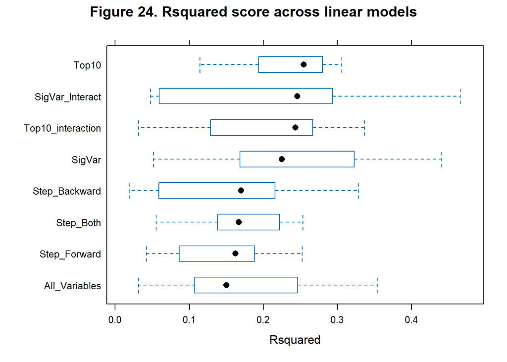

```r
# combining linear regression  results
results_compare_linear_models <- resamples(list(
  Top10             = regression_top10,
  Top10_interaction = regression_top_10_interaction,
  SigVar            = regression_sig_var,
  SigVar_Interact   = regression_sig_var_interaction,
  All_Variables     = regression_all_var,
  Step_Backward     = model_lm_backward,
  Step_Forward      = model_lm_forward,
  Step_Both         = model_lm_both))



# Summarize results linear regression

# Visualize RMSE comparison
#bwplot(results_compare_linear_models, metric = "RMSE")

# Visualize R-squared
bwplot(results_compare_linear_models, metric = "Rsquared",main = "Figure 24. Rsquared score across linear models")
```

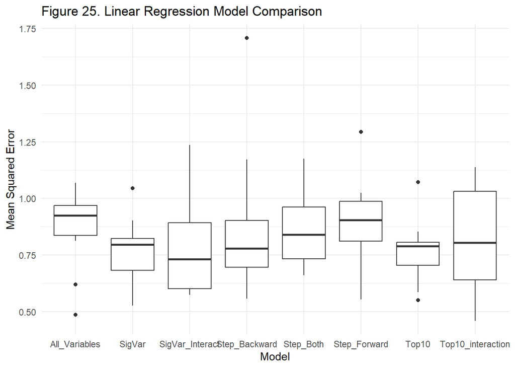

```r
###visualise MSE because that is our performance measure
# Extract RMSE values
linear_rmse <- results_compare_linear_models$values[, grep("RMSE", names(results_compare_linear_models$values))]

# Compute MSE from RMSE
linear_mse_vals <- linear_rmse^2

# Melt into long format
linear_mse_df <- reshape2::melt(linear_mse_vals, variable.name = "Model", value.name = "MSE")

# Clean up model names (remove "~RMSE")
linear_mse_df$Model <- gsub("~RMSE", "", linear_mse_df$Model)

# Visualize using boxplot
ggplot(linear_mse_df, aes(x = Model, y = MSE)) +
  geom_boxplot() +
  theme_minimal() +
  labs(title = "Figure 25. Linear Regression Model Comparison", y = "Mean Squared Error", x = "Model") +
  theme_minimal()
```

### KNN

In this analysis, a weighted K Nearest Neighbors (KNN) regression model was trained to predict students’ scores based on multiple predictors. The main goal was to compare different feature selection methods and see how they affect the model’s predictive performance.

First, we set a random seed (2025) to make the results reproducible and defined a 10-fold cross-validation setup using trainControl() from the caret package. This means the dataset was split into 10 parts: in each iteration, 9 folds were used for training and 1 for validation. This approach helps to get a more stable estimate of model performance and reduces overfitting compared to a single train/test split.

The first KNN model (model_knn_all) was trained using all available predictors. The tuneGrid defined the range of hyperparameters to explore; the number of neighbors (kmax), distance metrics and kernel functions. The model then automatically found the best combination of these parameters using cross-validation.

After fitting the full model, we calculated feature importance with varImp(). This step identifies which predictors had the most influence on the models output. The top ten most important features were selected and used to train a second KNN model (model_knn_top10_importance). This approach is similar to how significance-based selection is done in linear regression, focusing on the most influential predictors to simplify the model without losing too much predictive power.

Next, we applied a second feature selection method based on Spearman correlation. Each predictor’s correlation with the target variable (score) was computed using 10-fold cross-validation again and the top 10 most correlated predictors were selected. These were then used to train a third KNN model (model_knn_top10_corr).

1. KNN model with original data

```r
#target vars
y <- train_data_encode$score
x <- train_data_encode |> dplyr::select(-score)

###set seed and crossvalidation setup

colnames(train_data_encode) <- make.names(colnames(train_data_encode))

set.seed(2025)

tune_grid <- expand.grid(
  kmax = seq(1, 31, 2),
  distance = c(1, 2),
  kernel = c("rectangular", "triangular", "gaussian")
)


#KNN model with all vars
model_knn_all <- train(
  score ~ .,
  data = train_data_encode,
  method = "kknn",
  trControl = train_control,
  preProcess = c("center", "scale"),
  tuneGrid = tune_grid

)
```

2. Finding the most important features

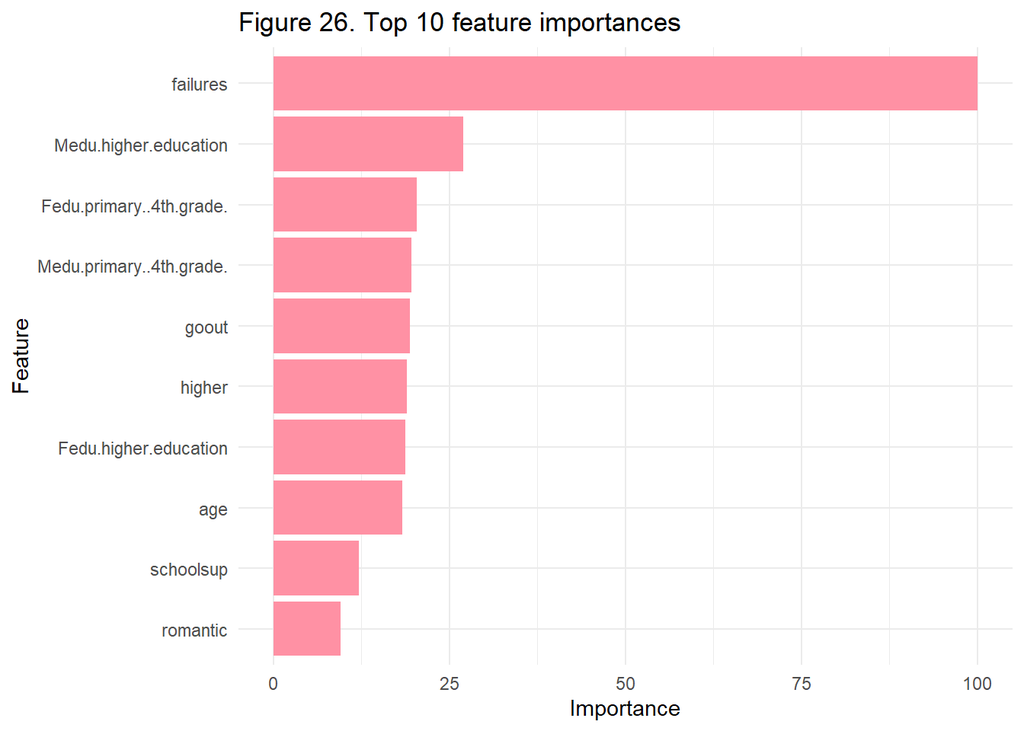

```r
#compute feature importance
varImp_knn <- varImp(model_knn_all, scale = TRUE)

#convert to tibble & select top 10
top_features_importance <- varImp_knn$importance |>
  tibble::as_tibble(rownames = "feature") |>
  dplyr::arrange(desc(Overall)) |>
  dplyr::slice(1:10)



#categorize importance levels (analogous to signficance)
importance_df <- varImp_knn$importance |>
  tibble::as_tibble(rownames="feature") |>
  dplyr::mutate(importance_level=dplyr::case_when(
    Overall >= 0.75 * max(Overall, na.rm=TRUE) ~ "highly important (more or same as 75%)",
    Overall >= 0.50 * max(Overall, na.rm=TRUE) ~ "moderately important (50-75%)",
    Overall >= 0.25 * max(Overall, na.rm=TRUE) ~ "low importance (25-50%)",
    TRUE ~ "negligible importance (<25%)"
  )) |>
  dplyr::arrange(desc(Overall))



#plotting feature importance
ggplot(top_features_importance, aes(x = reorder(feature, Overall), y = Overall)) +
  geom_bar(stat = "identity", fill = "#FF91A4") +
  coord_flip() +
  theme_minimal() +
  labs(title = "Figure 26. Top 10 feature importances",
       x = "Feature", y = "Importance")
```

3. KNN model with top 10 features from the feature selection

```r
#ensuring feature names are syntactically valid
top10_importance_features <- make.names(top_features_importance$feature)

#building safe formula
formula_top10_importance <- as.formula(paste("score ~", paste(top10_importance_features, collapse = "+")))

#training the model
model_knn_top10_importance <- train(
  formula_top10_importance,
  data = train_data_encode,
  method = "kknn",
  trControl = train_control,
  preProcess = c("center", "scale"),
  tuneGrid = tune_grid
)
```